# STATS707Assignment4

#### c) Find a point estimate, confidence and predition interval for average World Cup goals if the EPL and Bundesliga both average 4 goals per game. Is it sensible to use this model for this sort of prediction? Explain.

```r
newdata = data.frame(EPL=4, Bundesliga=4)

predict(eplNBundesliga.lm, newdata)
```

```
##        1
## 3.405318
```

```r
predict(eplNBundesliga.lm, newdata, interval = "confidence")
```

```
##        fit      lwr      upr
## 1 3.405318 2.462119 4.348518
```

```r
predict(eplNBundesliga.lm, newdata, interval = "prediction")
```

```
##        fit     lwr      upr
## 1 3.405318 2.37892 4.431716
```

```r
#its not a good idea to predict result through such models, since we are unable to identify importance and irrelevance of multiple variables, therefore it is wise to use recommend method to identity relevance of variables for prediction
```

#### d) It would also be possible to also include the La Liga and Serie A competitions in the model (please ignore the incomplete total and Champions league variables. Using stepwise selection and your chosen information criteria, try to come up with a better model. Report your findings, including diagnostics and any concerns.

```r
allLeague.lm <- lm(formula = WorldCup ~ EPL + Bundesliga + LaLiga + SerieA, data = soccer)

# backward Model
allLeague.modBackward <- step(allLeague.lm)
```

```
## Start:  AIC=-40.84
## WorldCup ~ EPL + Bundesliga + LaLiga + SerieA
##
##              Df Sum of Sq     RSS     AIC
## - SerieA      1  0.000343 0.37108 -42.825
## - LaLiga      1  0.001353 0.37209 -42.787
## - EPL         1  0.022849 0.39359 -42.001
## <none>                    0.37074 -40.838
## - Bundesliga  1  0.124683 0.49542 -38.780
##
## Step:  AIC=-42.83
## WorldCup ~ EPL + Bundesliga + LaLiga
##
##              Df Sum of Sq     RSS     AIC
## - LaLiga      1  0.001011 0.37209 -44.787
## - EPL         1  0.023896 0.39498 -43.952
## <none>                    0.37108 -42.825
## - Bundesliga  1  0.234190 0.60527 -37.976
##
## Step:  AIC=-44.79
## WorldCup ~ EPL + Bundesliga
##
##              Df Sum of Sq     RSS     AIC
## - EPL         1  0.029748 0.40184 -45.711
## <none>                    0.37209 -44.787
## - Bundesliga  1  0.243153 0.61525 -39.747
##
## Step:  AIC=-45.71
## WorldCup ~ Bundesliga
##
##              Df Sum of Sq     RSS     AIC
## <none>                    0.40184 -45.711
## - Bundesliga  1   0.23525 0.63709 -41.259
```

```r
allLeague.startmod <- lm(WorldCup ~ 1, data = soccer)

# Forward Model
allLeague.modForward <- step(allLeague.startmod, scope= list(upper = WorldCup ~ EPL + Bundesliga + LaLiga + SerieA, lower= WorldCup ~ 1), direction="forward")
```

```
## Start:  AIC=-41.26
## WorldCup ~ 1
##
##              Df Sum of Sq     RSS     AIC
## + Bundesliga  1  0.235252 0.40184 -45.711
## <none>                    0.63709 -41.259
## + SerieA      1  0.076574 0.56052 -41.051
## + EPL         1  0.021847 0.61525 -39.747
## + LaLiga      1  0.019373 0.61772 -39.691
##
## Step:  AIC=-45.71
## WorldCup ~ Bundesliga
##
##          Df Sum of Sq     RSS     AIC
## <none>                0.40184 -45.711
## + EPL     1 0.0297482 0.37209 -44.787
## + LaLiga  1 0.0068640 0.39498 -43.952
## + SerieA  1 0.0000252 0.40182 -43.711
```

```r
# Both Model
allLeague.modBoth <- step(allLeague.startmod, scope= list(upper = WorldCup ~ EPL + Bundesliga + LaLiga + SerieA, lower= WorldCup ~ 1), direction="both")
```

```
## Start:  AIC=-41.26
## WorldCup ~ 1
##
##              Df Sum of Sq     RSS     AIC
## + Bundesliga  1  0.235252 0.40184 -45.711
## <none>                    0.63709 -41.259
## + SerieA      1  0.076574 0.56052 -41.051
## + EPL         1  0.021847 0.61525 -39.747
## + LaLiga      1  0.019373 0.61772 -39.691
##
## Step:  AIC=-45.71
## WorldCup ~ Bundesliga
##
##              Df Sum of Sq     RSS     AIC
## <none>                    0.40184 -45.711
## + EPL         1  0.029748 0.37209 -44.787
## + LaLiga      1  0.006864 0.39498 -43.952
## + SerieA      1  0.000025 0.40182 -43.711
## - Bundesliga  1  0.235252 0.63709 -41.259
```

```r
# While looking into all the stepwise types it seems like predictive models are same with AIC of -45.71
```

#### e) Someone suggests that the start up of the Champions League format in 1992 affected the goals scored in the individual countries leagues, and therefore the relationship with the world cup. Consider predicting the world cup goals with a single league-sketch data that would indicate a main effect of the champions league, but no interaction. Make another sketch of data that would indicate a significant interaction. (Do not worry about making your sketch agree with the observed data for a particular league.) You may either make an electronic drawing, or take a picture of each sketch to embed in your assignment.

```r
championsnoNointeract.lm <- lm(WorldCup~EPL+Champions, data=soccer)
summary(championsnoNointeract.lm)
```

```
##
## Call:
## lm(formula = WorldCup ~ EPL + Champions, data = soccer)
##
## Residuals:
##        8        9       10       11       12
##  0.27135 -0.01925  0.02071 -0.17893 -0.09389
##
## Coefficients:
##             Estimate Std. Error t value Pr(>|t|)
## (Intercept)   3.1929     2.7724   1.152    0.369
## EPL          -0.9995     1.2629  -0.791    0.512
## Champions     0.7740     0.7184   1.077    0.394
##
## Residual standard error: 0.2401 on 2 degrees of freedom
##   (9 observations deleted due to missingness)
## Multiple R-squared:  0.378,  Adjusted R-squared:  -0.2439
## F-statistic: 0.6078 on 2 and 2 DF,  p-value: 0.622
```

```r
championsInteract.lm <- lm(WorldCup~EPL*Champions, data=soccer)
summary(championsInteract.lm)
```

```
##
## Call:
## lm(formula = WorldCup ~ EPL * Champions, data = soccer)
##
## Residuals:
##        8        9       10       11       12
##  0.15952  0.03564 -0.14060 -0.04300 -0.01157
##
## Coefficients:
##               Estimate Std. Error t value Pr(>|t|)
## (Intercept)     -90.58      79.92  -1.133    0.460
## EPL              34.40      30.18   1.140    0.458
## Champions        40.22      33.61   1.197    0.443
## EPL:Champions   -14.87      12.67  -1.174    0.449
##
## Residual standard error: 0.2202 on 1 degrees of freedom
##   (9 observations deleted due to missingness)
## Multiple R-squared:  0.7385, Adjusted R-squared:  -0.04616
## F-statistic: 0.9412 on 3 and 1 DF,  p-value: 0.6215
```

```r
# it is visible that AIC now dropped to 21.02 for entries with champions Leage
```

[output not shown]

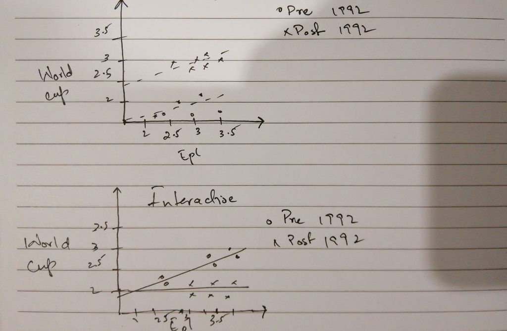

## Question 2

### The following table gives the number of full time and part time academic employees of different ranks at the University of Michigan.

### ——————————————–

### Assistant Professor | 716 | 83

### Associate Professor | 727 | 86

### Full Professor | 1226 | 330

#### a) Is Full Time/Part Time status independent of rank? Give your computer output and state your conclusion.

```r
entries <- c(716 , 83, 727, 86, 1226, 330)

x <- matrix(entries, ncol=2, byrow=TRUE)
chisq.test(x)
```

```
##
##  Pearson's Chi-squared test
##
## data:  x
## X-squared = 68.631, df = 2, p-value = 1.25e-15
```

```r
# since pvalue < 0.0001 therefore Rank and fulltime/parttime roles are not independent
```

#### b) Show how the degrees of freedom for the test is computed.

```r
#df = (Colunm - 1) X (Row - 1)
(2 - 1) * (3 - 1)
```

```
## [1] 2
```

#### c) Show how the expected value for full time Associate Professors is computed.

```r
total <- sum(entries)
PFullTime <- (716 + 727 + 1226)/total
PAssosiate <- (727 + 86)/total

PFullTimeAssosiate <- PFullTime * PAssosiate

PFullTimeAssosiate * total
```

```
## [1] 684.9422
```

#### d) A newspaper article suggests Assistant Professors are more likely that other ranks to be part time because of parenting duties. Is this a correct interpretation of this data? Explain.

```r
x - chisq.test(x)$expected
```

```
##           [,1]      [,2]
## [1,]  42.85259 -42.85259
## [2,]  42.05777 -42.05777
## [3,] -84.91035  84.91035
```

```r
# Thats not true, In fact Full Professors are the ones that more likely be part timer.
```

## Question 3

### A university has as its goal to have 82% domestic students with full government funding, 14.5% international students, and 3.5% other students. A sample of 1000 students shows 807 fully funded domestic students, 167 international students, and 26 other students.

#### a) Are the universitys students distributed in the desired way? Perform the relevant hypothesis test and give your conclusion.

```r
x <- c(807, 167, 26)
(test <- chisq.test(x, p = c(.82, .145, .035)))
```

```
##
##  Chi-squared test for given probabilities
##
## data:  x
## X-squared = 5.8583, df = 2, p-value = 0.05344
```

```r
test$expected
```

```
## [1] 820 145  35
```

```r
# Based on p-value 0.05344 which is greater than .0001 we cannot reject null Hypothesis
```

#### b) Someone suggests using a sample of 100 students rather than 1000 students, so each can be interviewed personally and asked a more extensive set of questions. Discuss the pros and cons of this idea with respect to the test performed above.

```r
# sampling 100 students out of another sample makes no sense and it would result abnormalities in distribution. Theoritically it will have a similar result as above. but practically it could cause serious distribution change since we are taking 1/10th of the sample and could change p-value drastically.
```